# DataViz in R

Florian Pethig, Jean-Philippe Rodrigue

3/5/2020

### INTRO

As Business Data Analysts (BDAs) at zeroG, we always try to create great visualizations and share them with our fellow BDAs during our monthly knowledge exchange. For a long time, we wanted to get our head around R visualizations. So we kicked off a little side project to analyze and visualize Lufthansa reviews on Tripadvisor.

### DATA

The data we are using throughout this blog article contains 1,385 English reviews of Lufthansa passengers who flew to or from Frankfurt. The reviews were published on Tripadvisor between January 2016 and January 2017. The data set contains the following variables.

| Variable | Description | Values |
| --- | --- | --- |
| review_id | Unique review ID |  |
| review_rating | Overall rating | 1 = terrible, 2 = poor, 3 = average, 4 = very good, 5 = excellent |
| review_date | Date review was published |  |
| travel_date | Date traveled |  |
| date_diff | Difference between travel_date and review_date | Months |
| booking_class | Booking class | Economy, Premium Economy, Business Class, First Class |
| flight_origin | City of origin |  |
| flight_destination | City of destination |  |

### RESEARCH QUESTIONS

Our guiding research question was to understand how people perceive their flight experiences online. In particular, we were interested in the routes passengers most frequently reviewed and for which routes they reported the best/worst experience. Furthermore, we wanted to know whether there are any quality differences across different booking classes.

### LOLLIPOP

For the first plot, we chose a lollipop chart because it reduces thick bars of a bar chart into thin lines and therefore places more emphasis on the value. The results indicate that Frankfurt-Singapore and Singapore-Frankfurt are by far the most reviewed routes with 60+ reviews.

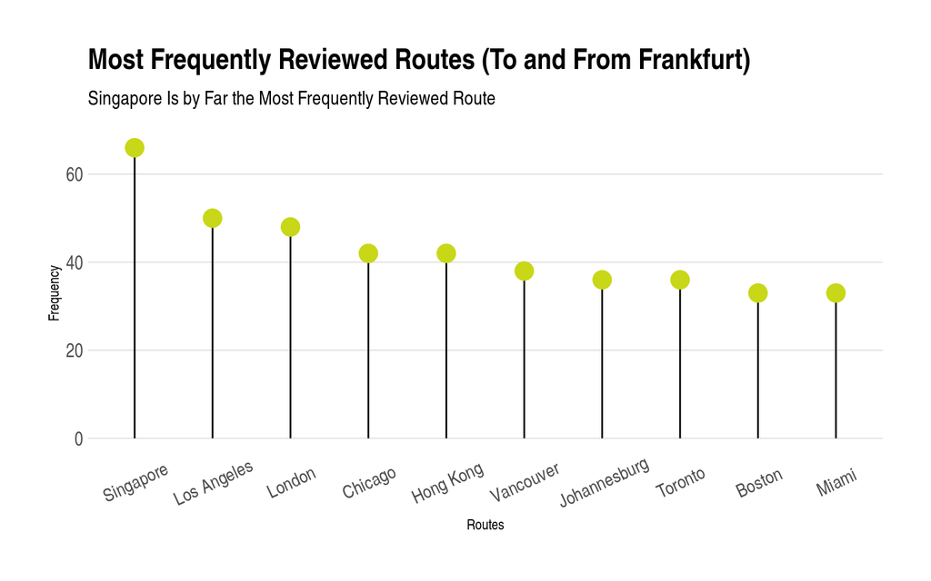

```r
# libraries
library(dplyr)
library(ggplot2)
library(hrbrthemes)

# load data from github
lh <- read.csv("https://raw.githubusercontent.com/florianpethig/dataviz/master/LH_reviews.csv", sep=';')

# prepare data
lh$not_fra <- paste(lh$flight_origin, lh$flight_destination, sep = "")
lh$not_fra <- gsub("Frankfurt", "", lh$not_fra)
lollipop <- as.data.frame(lh %>% group_by(not_fra) %>% summarize('count' = n()))
lollipop <- lollipop[order(lollipop$count, decreasing=TRUE), ]
first_n <- filter(head(lollipop, n=10))

# plot lollipop
plot1 <- ggplot(first_n) +
  geom_segment(aes(x=reorder(not_fra, -count),
                   xend=not_fra,
                   y=0,
                   yend=count)) +
  geom_point(size=5, color="#C8D717", aes(x=not_fra, y=count)) +
  labs(title="Most Frequently Reviewed Routes (To and From Frankfurt)",
       subtitle = "Singapore Is by Far the Most Frequently Reviewed Route",
       x="Routes",
       y="Frequency") +
  theme_ipsum() +
  theme(axis.text.x = element_text(angle=25, vjust=0.6),
        panel.grid.minor = element_blank(),
        panel.grid.major.x = element_blank(),
        axis.title.x = element_text(hjust = 0.5),
        axis.title.y = element_text(hjust = 0.5)
        )
plot1
```

### DOT

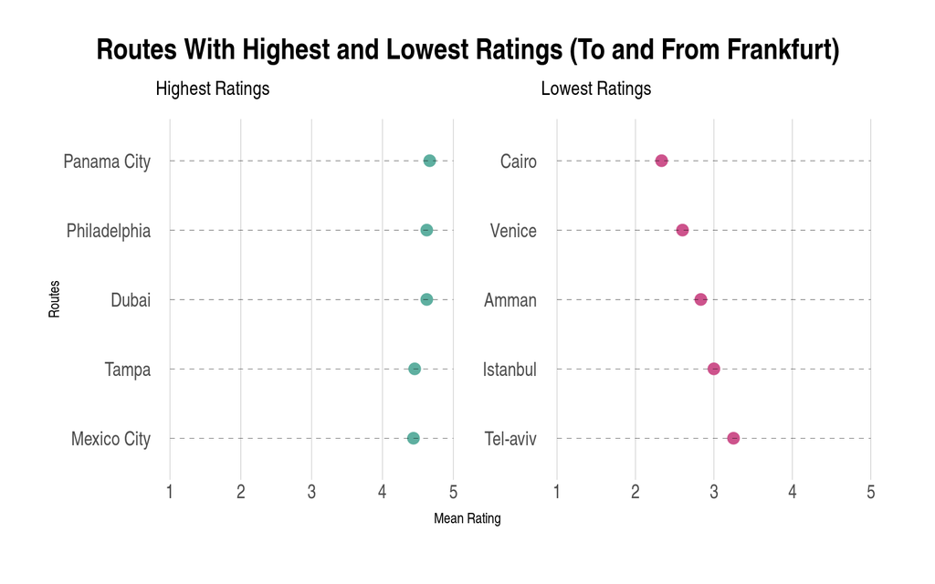

```r
library(magrittr)
library(ggpubr)

dot <- as.data.frame(lh %>% group_by(not_fra) %>% summarize('count' = n(),
                                                            'mean' = mean(review_rating)))
dot <- dot[order(dot$mean, decreasing=TRUE), ]
dot <- filter(dot, count >= 5)
first_mean <- filter(head(dot, n=5))
last_mean <- filter(tail(dot, n=5))

# Plot2 - Dot Plots
plot2 <- ggplot(first_mean, aes(x=reorder(not_fra, mean), y=mean)) +
  geom_point(col="#5EAFA0", size=3) +   # Draw points
  geom_segment(aes(x=not_fra,
                   xend=not_fra,
                   y=min(1),
                   yend=max(5)),
               linetype="dashed",
               size=0.1) +   # Draw dashed lines
  labs(subtitle="Highest Ratings",
       x = "Routes",
       y = "") +
  theme_ipsum() +
  coord_flip() +
  theme(panel.grid.major.y = element_blank(),
        panel.grid.minor = element_blank(),
        axis.title.x = element_text(hjust = 0.5),
        axis.title.y = element_text(hjust = 0.5),
        plot.margin = margin(30, 0, 30, 30)
        )

plot3 <- ggplot(last_mean, aes(x=reorder(not_fra, -mean), y=mean)) +
  geom_point(col="#CD538C", size=3) +   # Draw points
  geom_segment(aes(x=not_fra,
                   xend=not_fra,
                   y=min(1),
                   yend=max(5)),
               linetype="dashed",
               size=0.1) +   # Draw dashed lines
  labs(subtitle="Lowest Ratings",
       x = "",
       y = "") +
  theme_ipsum() +
  coord_flip() +
  theme(panel.grid.major.y = element_blank(),
        panel.grid.minor = element_blank(),
        axis.title.x = element_text(hjust = 0.5),
        axis.title.y = element_text(hjust = 0.5),
        plot.margin = margin(30, 30, 30, 0)
        )

plot2_3 <- ggarrange(plot2, plot3)
annotate_figure(plot2_3,
                top = text_grob("Routes With Highest and Lowest Ratings (To and From Frankfurt)",
                                face = "bold",
                                family = "Arial Narrow",
                                size = 18,
                                y = -0.5),
                bottom = text_grob("Mean Rating",
                                   family = "Arial Narrow",
                                   size = 9,
                                   y = 3))
```

### MOSAIC

We wanted to know whether there were any differences in the average rating between the different booking classes. We used a mosaic plot because it divides the different booking classes into their relative proportions. The plot shows that the majority of travelers reviewed “Economy”, followed by “Business Class”, “Premium Economy”, and “First Class”. Interestingly, travelers had a more positive perception of Lufthansa’s Premium Economy Class than of its Business Class.

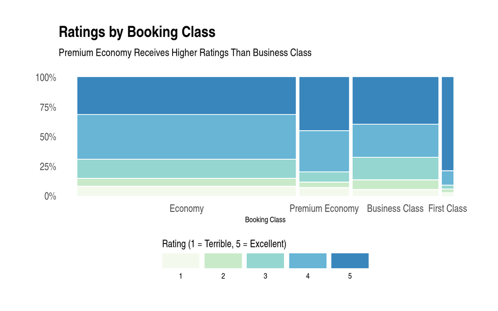

```r
library(ggmosaic)

ordered <- factor(lh$booking_class, levels = c("Economy",
                                               "Premium Economy",
                                               "Business Class",
                                               "First Class"))
#Mosaic Plot
plot_mosaic <- ggplot(data = lh) +
  geom_mosaic(mapping = aes(x = product(review_rating, ordered), fill = review_rating), na.rm = TRUE) +
  scale_y_continuous(labels = scales::percent) +
  scale_fill_brewer(palette = "GnBu") +
  labs(title = "Ratings by Booking Class",
       subtitle = "Premium Economy Receives Higher Ratings Than Business Class",
       fill = "Rating (1 = Terrible, 5 = Excellent)",
       x = "Booking Class",
       y = '') +
  guides(fill = guide_legend(x = element_blank(),
                             title.position = "top",
                             label.position = "bottom",
                             keywidth = 3,
                             nrow = 1)) +
  theme_ipsum() + theme(legend.position = "bottom",
                        axis.title.x = element_text(hjust = 0.5),
                        panel.grid.major = element_blank(),
                        panel.grid.minor = element_blank())
plot_mosaic
```